# Petroleum consumed by the residential sector in the US

Xinyu Yao

## Materials and Methods

Data were downloaded from U.S. Energy Information Administration (eia) (https://www.eia.gov/totalenergy/data/monthly/index.php). DATA CATEGORIES >> Petroleum >> Residential and commercial sectors. Total Petroleum Consumed by the Residential Sector from Jan 1984 to Sep 2019 is extracted and used for time series analysis.

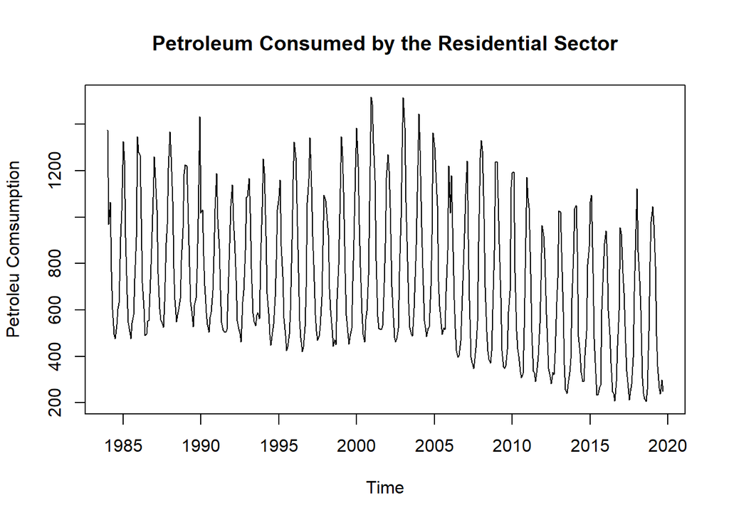

1. The data contains petroleum consumed (in Thousand Barrels per Day) by the residential sector in the US from Jan, 1984 to Sep, 2019. In this case, the data is in a series of particular time periods from Jan, 1984 to Sep, 2019. The trend and the seasonal effects can be estimated through the analysis, as well as the forcast of petroleum consumption. With these information, some adjustment to the global oil market can be made, such as reduction in oil production.
2. The variations in petroleum consumed seem to vary over the time.
3. The time series is not stationary, as the series is not fluctuate about a constant value. Therefore transformation and estimation of the trend and the seasonal effects are needed in order to carry out the analysis. AS the graph of the time series falls to the left and rises to the right, then the degree for polynomial trend estimation should be odd. In addition, there are two peaks in the graph, so the degree of 5 for polynomial trend estimation was chosen.

The function ‘trndseas’ fits a trend plus seasonal for the “best” Box-Cox transformation with a vector of lambda values: -1, -0.95, -0.90, …, 0.95, 1. Then the best value of lambda, at which r-square is maximum, turns out to be equal to about 0.6.

Then I fit a trend plus seasonal for the “best” Box-Cox transformation with a value of lambda equal to 0.6.

Plots for the trend, seasonals and the rough after transformation are presented below.

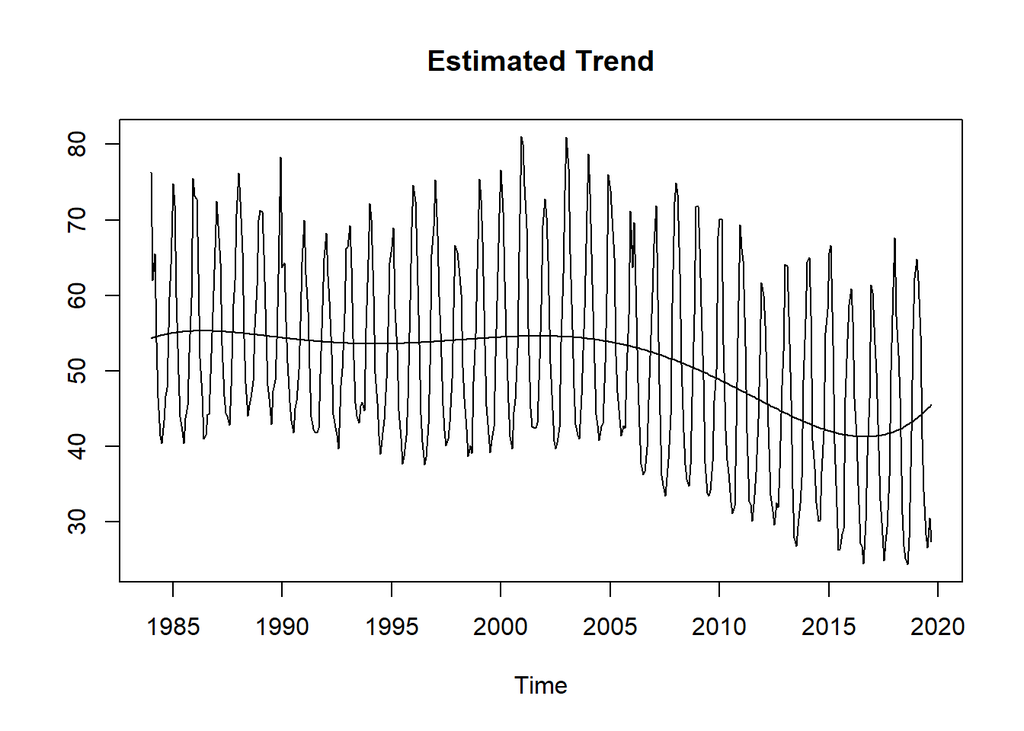

Plot of trend shows that there is a significant decline in petroleum consumed by the residential sector in the US since 2003. It remained stable or showed a slight increase since 2016. Overall, petroleum consumed by the residential sector in the US over last 15 years is less than two decades ago.

[figure not shown]

https://www.eia.gov/energyexplained/use-of-energy/homes.php

It shows electricity consumption increased significantly while petroleum consumption decrease. The significant decline in petroleum consumption could partially be explained by change in energy structure of residential sector in the US.

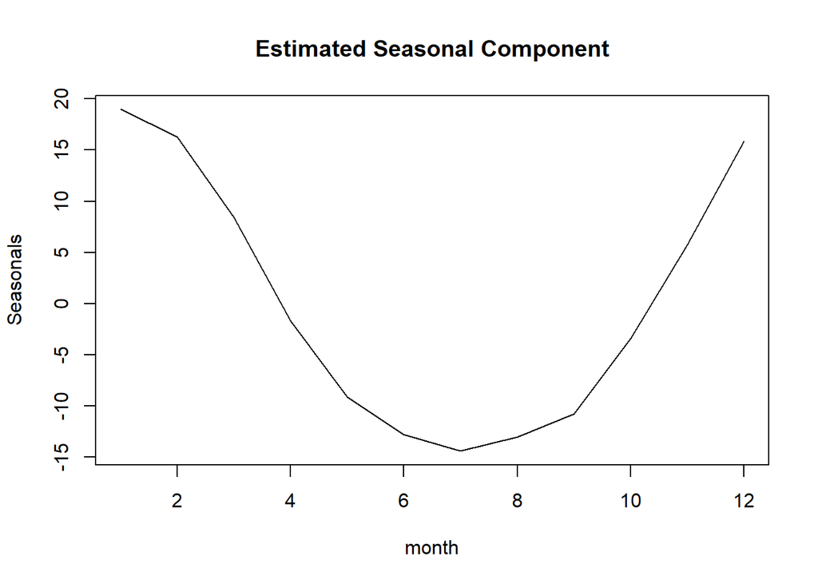

Over a year, petroleum is consumed most in January and least in July, because Petroleum — fuel oil and propane (liquefied petroleum gas or LPG), together with nature gas, is all primarily used for space heating and water heating.

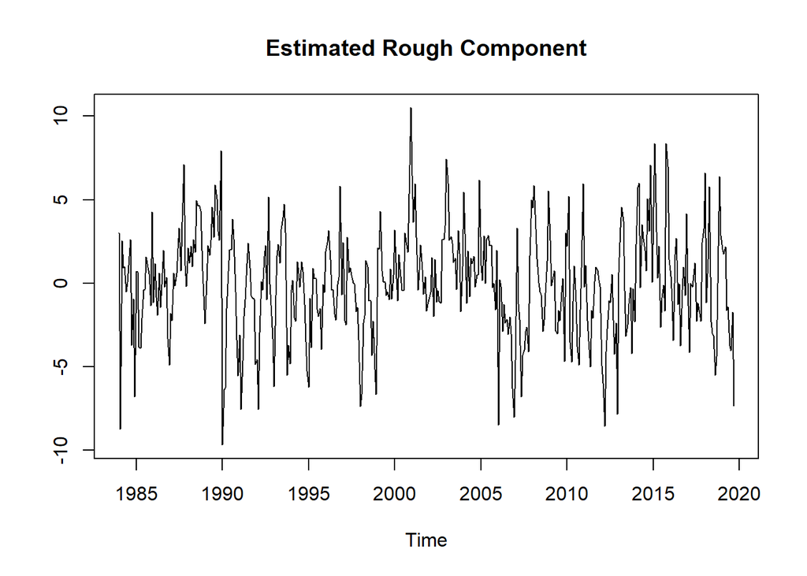

### ARIMA model

Here I used the time series data from Jan 1984 to Sep 2018 to train models and data from Oct 2018 to Sep 2019 to test if the models perform well in prediction.

Notice that the rough component appears approximately stationary with no long-term trend: it exhibits a definite tendency to return to its mean, albeit somewhat lazy ones.

The ACF plot confirms a slight amount of positive autocorrelation:

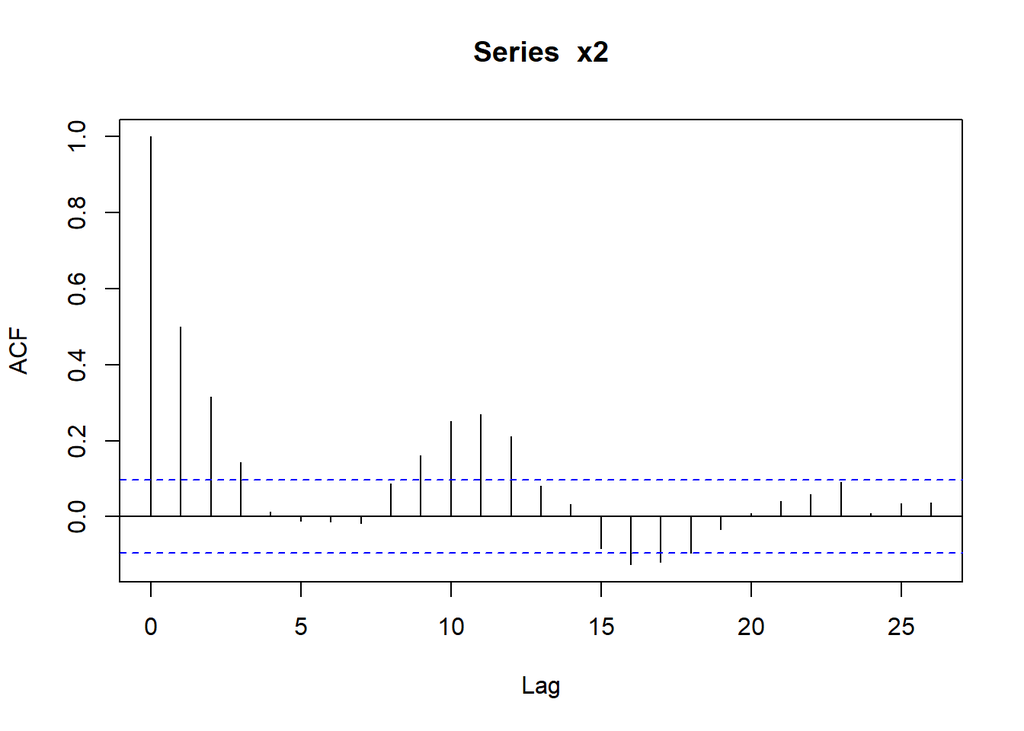

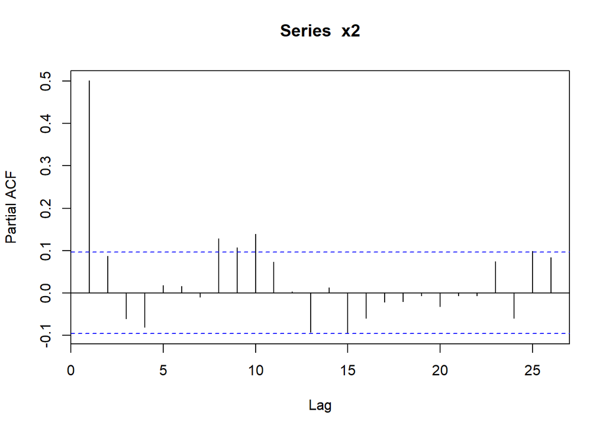

Is difference needed? Because the amount of autocorrelation which remains is small, it appears as though the series may be satisfactorily stationary. If we try one order of differencing–i.e., an ARIMA(0,1,0) model–just to see what the effect is, we obtain the following time series plot:

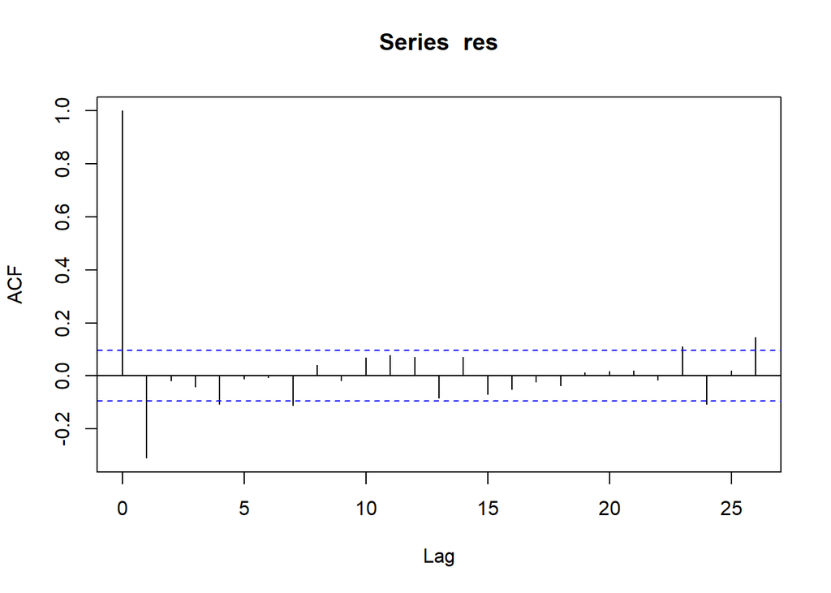

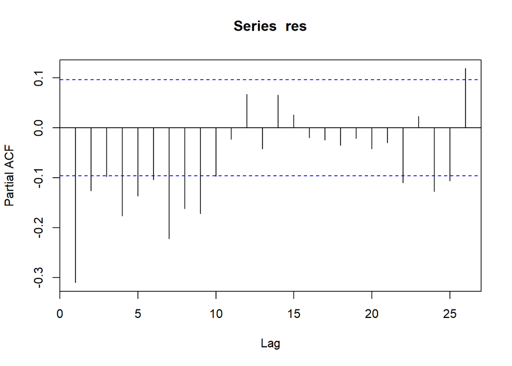

```
##           Length Class  Mode
## coef        0    -none- numeric
## sigma2      1    -none- numeric
## var.coef    0    -none- numeric
## mask        0    -none- logical
## loglik      1    -none- numeric
## aic         1    -none- numeric
## arma        7    -none- numeric
## residuals 417    ts     numeric
## call        3    -none- call
## series      1    -none- character
## code        1    -none- numeric
## n.cond      1    -none- numeric
## nobs        1    -none- numeric
## model      10    -none- list
```

Let’s take another look at the ACF and PACF plot:

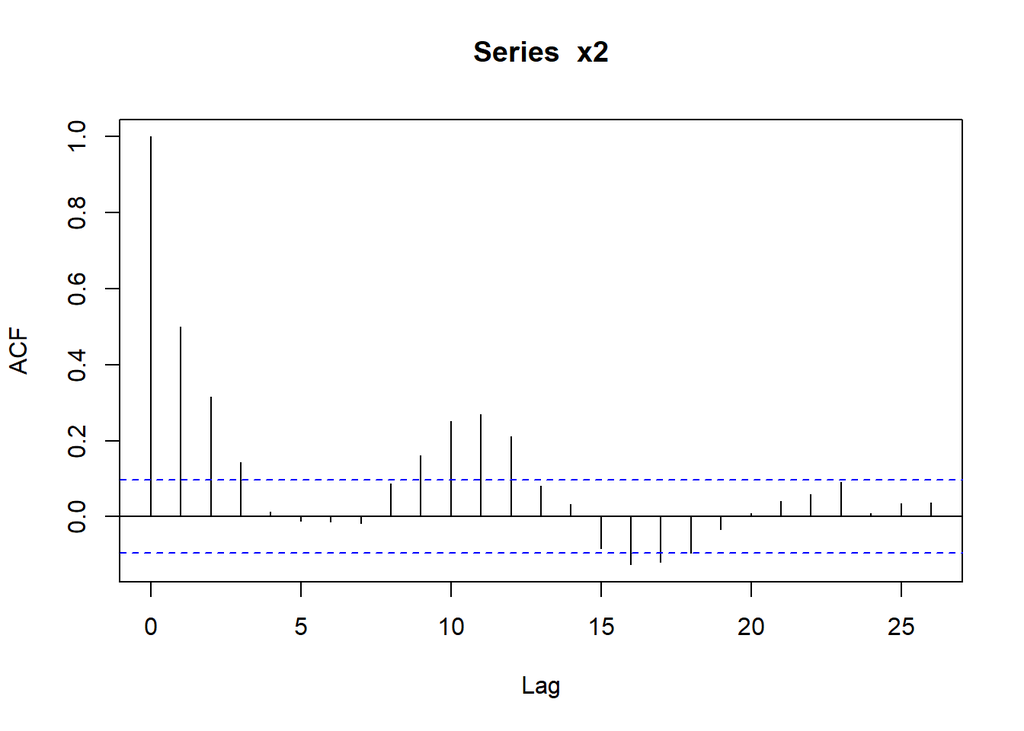

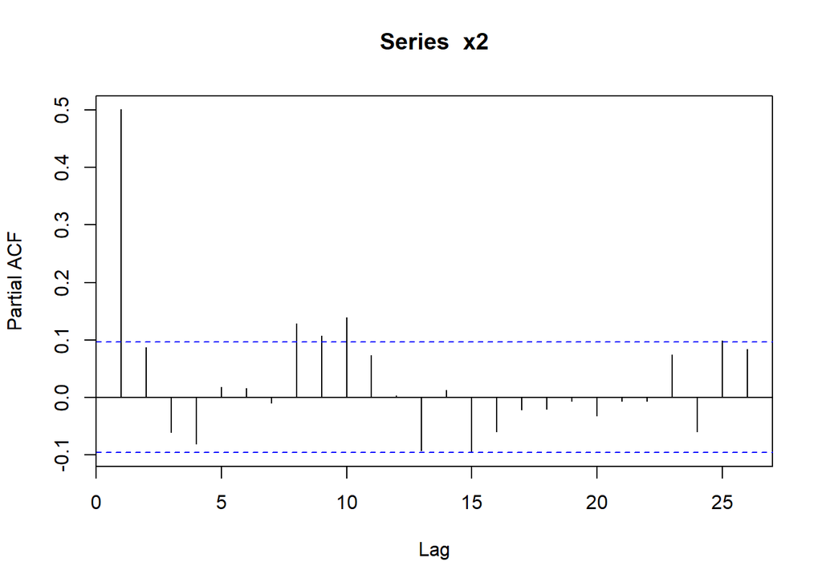

```
##           Length Class  Mode
## coef        2    -none- numeric
## sigma2      1    -none- numeric
## var.coef    4    -none- numeric
## mask        2    -none- logical
## loglik      1    -none- numeric
## aic         1    -none- numeric
## arma        7    -none- numeric
## residuals 417    ts     numeric
## call        3    -none- call
## series      1    -none- character
## code        1    -none- numeric
## n.cond      1    -none- numeric
## nobs        1    -none- numeric
## model      10    -none- list
```

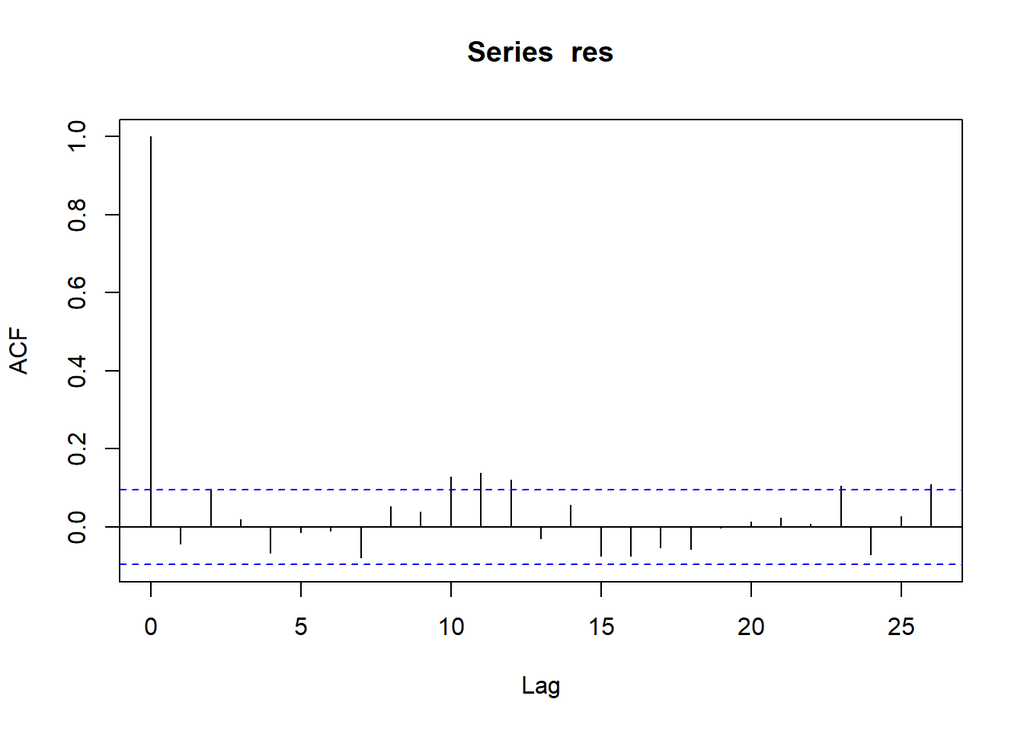

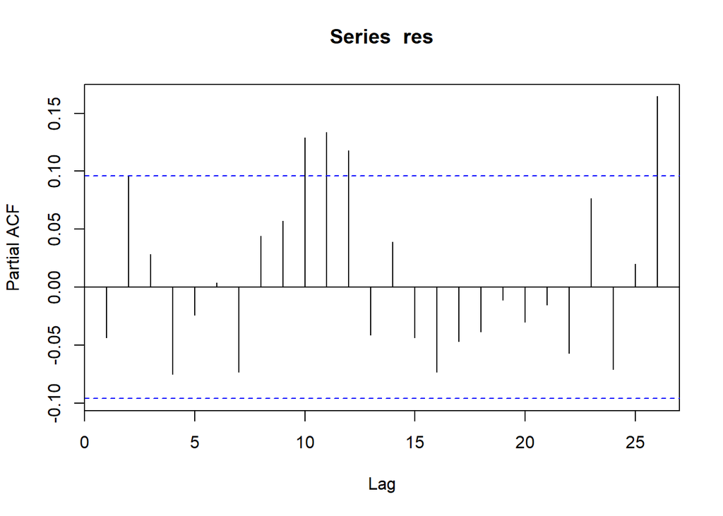

```
##
##  Box-Ljung test
##
## data:  res
## X-squared = 42.521, df = 20, p-value = 0.002364
```

The Ljung-Box test shows that the autocorrelations of ARIMA(1,0,0) are significantly different from zeros, so more AR and/or MA terms need to be included. However, as it is possible for an AR term and an MA term to cancel each other’s effects, so ARIMA models cannot be identified by “backward stepwise” approach. In other words, we cannot begin by including several terms of each kind and then throwing out the ones whose estimated coefficients are not significant. Instead, we normally follow a “forward stepwise” approach, adding terms of one kind or the other as indicated by the appearance of the ACF and PACF plots.

```
##           Length Class  Mode
## coef        5    -none- numeric
## sigma2      1    -none- numeric
## var.coef   25    -none- numeric
## mask        5    -none- logical
## loglik      1    -none- numeric
## aic         1    -none- numeric
## arma        7    -none- numeric
## residuals 417    ts     numeric
## call        3    -none- call
## series      1    -none- character
## code        1    -none- numeric
## n.cond      1    -none- numeric
## nobs        1    -none- numeric
## model      10    -none- list
```

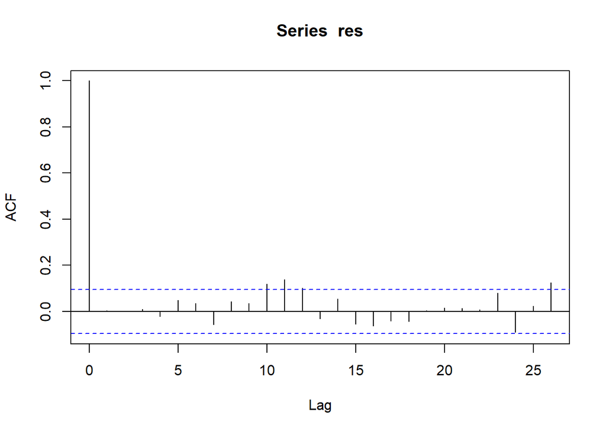

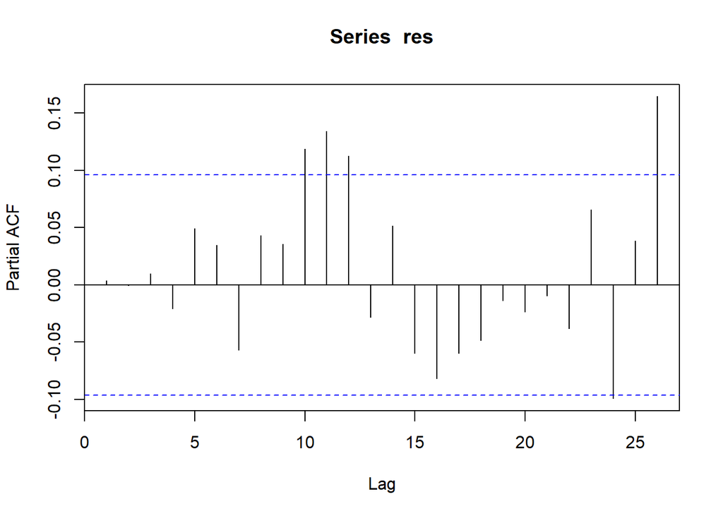

```
##
##  Box-Ljung test
##
## data:  res
## X-squared = 29.346, df = 20, p-value = 0.08116
```

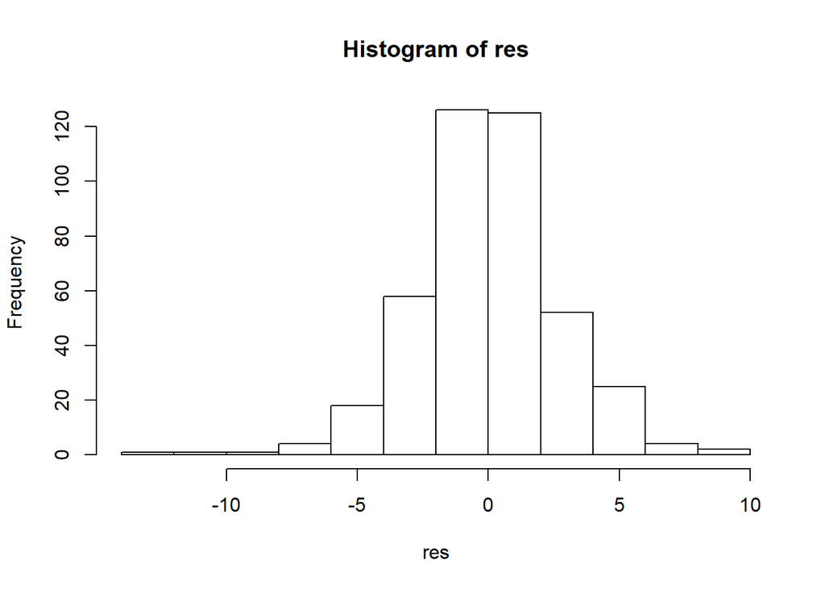

The ARIMA model fitted would be ARIMA(2,0,2), following the “forward stepwise” approach.

The ACF and PACF plots show that autocorrelations and partial autocorrelations are within the significant bounds, though some touch and exceed the significant bounds, which could creat suspect whether they’re significant or not. The Ljung-Box test rejects the hypothesis that the autocorrelations are significantly different from zeros. Overall, the residuals of ARIMA(2,0,2) resemble white noise, so the model seems to be a good fit.

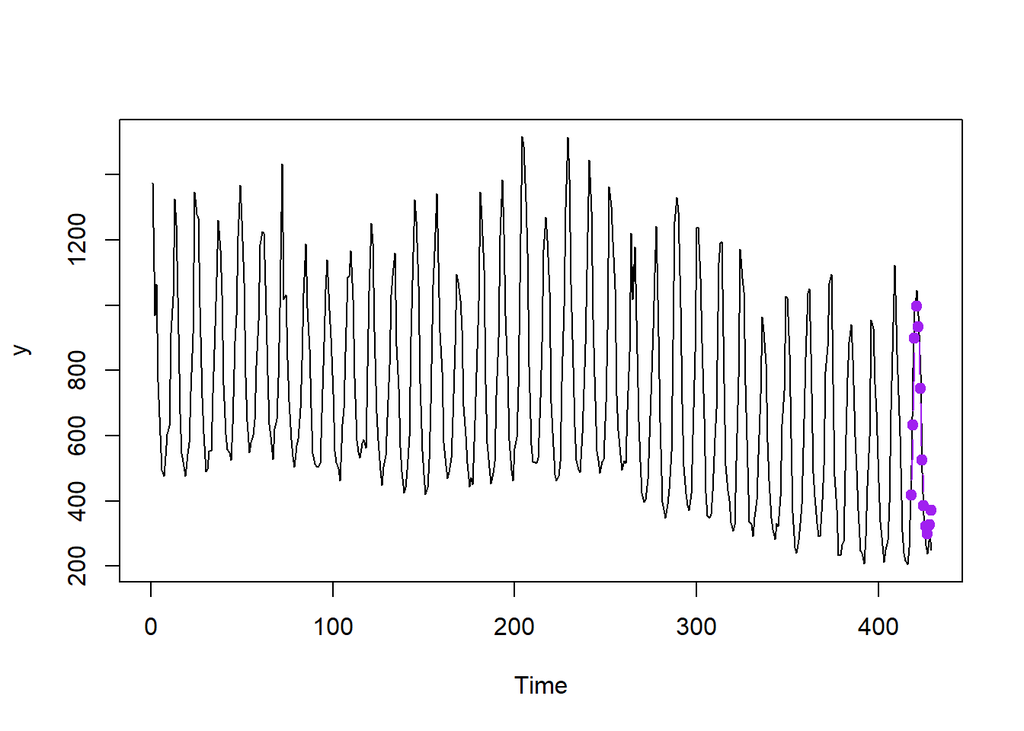

```
##         true  predict       diff
##  1:  508.071 418.7198   89.35117
##  2:  807.937 633.0122  174.92483
##  3:  979.934 898.3626   81.57137
##  4: 1044.923 995.5844   49.33861
##  5:  969.628 933.3696   36.25843
##  6:  789.298 744.7961   44.50186
##  7:  488.420 524.7071  -36.28712
##  8:  357.700 384.1147  -26.41467
##  9:  262.760 322.9846  -60.22464
## 10:  237.053 299.6666  -62.61359
## 11:  298.462 326.5969  -28.13489
## 12:  249.598 370.0731 -120.47510
```

RMSE of using ARIMA model is `79.4949595`.

### Holt-Winters model

[output not shown]

[output not shown]

[interactive chart not shown]

```
##         true  predict       diff
##  1:  508.071 426.9623  81.108662
##  2:  807.937 651.0501 156.886936
##  3:  979.934 885.2332  94.700759
##  4: 1044.923 985.0226  59.900418
##  5:  969.628 861.2814 108.346619
##  6:  789.298 694.2938  95.004182
##  7:  488.420 497.9025  -9.482477
##  8:  357.700 317.5644  40.135568
##  9:  262.760 239.4870  23.273023
## 10:  237.053 207.9389  29.114123
## 11:  298.462 217.1551  81.306925
## 12:  249.598 268.0792 -18.481230
```

RMSE of using Holt-Winters model is `78.8223863`.

```
##     this_year last_year     diff
##  1:   508.071   394.669  113.402
##  2:   807.937   680.007  127.930
##  3:   979.934   947.881   32.053
##  4:  1044.923  1122.411  -77.488
##  5:   969.628   850.425  119.203
##  6:   789.298   727.067   62.231
##  7:   488.420   599.857 -111.437
##  8:   357.700   306.670   51.030
##  9:   262.760   240.614   22.146
## 10:   237.053   216.993   20.060
## 11:   298.462   205.012   93.450
## 12:   249.598   256.332   -6.734
```

However, if we assume that petroleum consumed from Oct 2018 to Sep 2019 is the same as from Oct 2017 to Sep 2018, RMSE would be `81.1548417`.

## Results

Holt-Winters model did best in prediction.

```
## Holt-Winters exponential smoothing with trend and additive seasonal component.
##
## Call:
## HoltWinters(x = train)
##
## Smoothing parameters:
##  alpha: 0.2651183
##  beta : 0
##  gamma: 0.3508277
##
## Coefficients:
##              [,1]
## a    540.37391377
## b     -0.02980303
## s1  -113.38177307
## s2   110.73575628
## s3   344.94873651
## s4   444.76788043
## s5   321.05648225
## s6   154.09872250
## s7   -42.26281540
## s8  -222.57105732
## s9  -300.61870927
## s10 -332.13700648
## s11 -322.89100590
## s12 -271.93704763
```

The estimated values of alpha, beta and gamma are `0.2651183`, `0` and `0.3508277` respectively. The value of alpha is relatively low, indicating that the estimate of the level at the current time point is based upon both recent observations and some observations in the more distant past. The value of beta is 0.00, indicating that the estimate of the slope b of the trend component is not updated over the time series, and instead is set equal to its initial value. This makes good intuitive sense, as the level changes quite a bit over the time series, but the slope b of the trend component remains roughly the same. The value of gamma is low also, indicating that the estimate of the seasonal component at the current time point is based upon both recent observations and some observations in the more distant past.

## Conclusion and Discussion

There is a significant decline in petroleum consumed by the residential sector in the US since 2003. It remained stable or showed a slight increase since 2016. Overall, petroleum consumed by the residential sector in the US over last 15 years is less than two decades ago.

Over a year, petroleum is consumed most in January and least in July, because Petroleum — fuel oil and propane (liquefied petroleum gas or LPG), together with nature gas, is all primarily used for space heating and water heating.

Holt-Winters model did best in forecasting petroleum consumed from Oct 2018 to Sep 2019 based on the data from Jan, 1984 to Sep 2018.